# ANÁLISIS OFENSIVO DE LA TEMPORADA 2024 EN LA LIGA AMERICA DE LAS GRANDES LIGAS DE BEISBOL

Author

Diego Perez

## INTRODUCCIÓN

El beisbol de la *Major League Baseball* (MLB) es catalogado como el de más alto nivel y el de mayor competitividad a nivel mundial. La liga americana esta compuesta por quince equipos entre los cuales se encuentra el maximo ganador de la liga: los New York Yankees.

En el presente proyecto analizaremos los equipos de la liga americana y su rendimiento ofensivo en el año 2024 para determinar:

##### 1. ¿Qué equipo fue la mejor ofensiva del año 2024 en la MLB?

##### 2. ¿Qué equipo fue la peor ofensiva del año 2024 en la MLB?

## DEFINICIÓN DE NUESTRAS VARIABLES

### AB (Turnos al Bate)

Un turno al bate (AB) es una aparición oficial al plato de un jugador. Se utiliza como denominador para calcular el promedio de bateo y el porcentaje de slugging.

### Hits (H)

Un hit ocurre cuando un bateador golpea la pelota en territorio válido y llega a una base de forma segura, sin el beneficio de un error de un fildeador o de una jugada de selección.

### HR (Cuadrangular)

Un cuadrangular es un hit en el que el bateador golpea una pelota válida de tal manera que puede recorrer todas las bases y anotar una carrera sin ser puesto out y sin la ayuda de un error. Lo más común es que la pelota sea golpeada fuera del campo de juego en territorio válido (por encima de la cerca del jardín).

### AVG (Promedio de Bateo)

El promedio de bateo es una de las estadísticas más antiguas y fundamentales utilizadas para medir el éxito de un bateador. Representa la proporción de los turnos al bate de un jugador que resultan en un hit.

### SLG (Porcentaje de Slugging)

El porcentaje de slugging mide el poder de un bateador calculando el número total de bases que un jugador registra por turno al bate. A diferencia del promedio de bateo, le da más peso a los extrabases.

### OBP (Porcentaje de Embasado)

El porcentaje de embasado mide la frecuencia con la que un bateador llega a base por aparición al plato, independientemente de cómo llegó allí (excluyendo errores). Incluye hits, bases por bolas y veces que fue golpeado por un lanzamiento.

## VALORES ESTADÍSTICOS Y ANÁLISIS EXPLORATORIO

A continuación, se presentan tablas resumenes, graficas y valores estadísticos que configuran a los mejores y peores equipos ofensivos de la liga americana en el mejor beisbol del mundo en el año 2024.

## TABLA INTERACTIVA

Aquí podrás visualizar los datos ofensivos más destacados de tú equipo favorito

|  | TEAM | LEAGUE | AB | H | HR | AVG | OBP | SLG |
| --- | --- | --- | --- | --- | --- | --- | --- | --- |
| 1 | New York Yankees | AL | 5450 | 1352 | 237 | 248 | 333 | 429 |
| 2 | Baltimore Orioles | AL | 5567 | 1391 | 235 | 250 | 315 | 435 |
| 3 | Oakland Athletics | AL | 5432 | 1267 | 196 | 233 | 301 | 393 |
| 4 | Boston Red Sox | AL | 5577 | 1404 | 194 | 252 | 319 | 423 |
| 5 | Houston Astros | AL | 5530 | 1448 | 190 | 262 | 322 | 418 |
| 6 | Cleveland Guardians | AL | 5310 | 1263 | 185 | 238 | 307 | 395 |
| 7 | Seattle Mariners | AL | 5330 | 1195 | 185 | 224 | 311 | 376 |
| 8 | Minnesota Twins | AL | 5490 | 1352 | 183 | 246 | 315 | 411 |
| 9 | Texas Rangers | AL | 5472 | 1302 | 176 | 238 | 305 | 380 |
| 10 | Kansas City Royals | AL | 5421 | 1343 | 170 | 248 | 306 | 403 |

[output cut: 5 more lines]

## TURNOS AL BATE (AB)

##### Resumen estadísticas descriptivas (AB)

```
   Min. 1st Qu.  Median    Mean 3rd Qu.    Max.
   5310    5386    5432    5437    5481    5577
```

Los valores máximos (5.577) y valores mínimos (5.310) son el indicador de los extremos de nuestra variable.

El primer quartil nos indica que el 25% de los equipos se encuentran por debajo de los 5.386 turnos al bate. Mientras qué, el tercer quartil nos indica que el 75% de los equipos se encuentran por debajo de los 5.481 turnos.

Encontramos una media y mediana muy similares, lo que nos hace referirnos a que los datos de los **Turnos al Bate** estan distribuidos de manera uniforme o simétrica alrededor del centro tal como se mostrará en la figura a continuación:

##### Distribución de Frecuencia (AB)

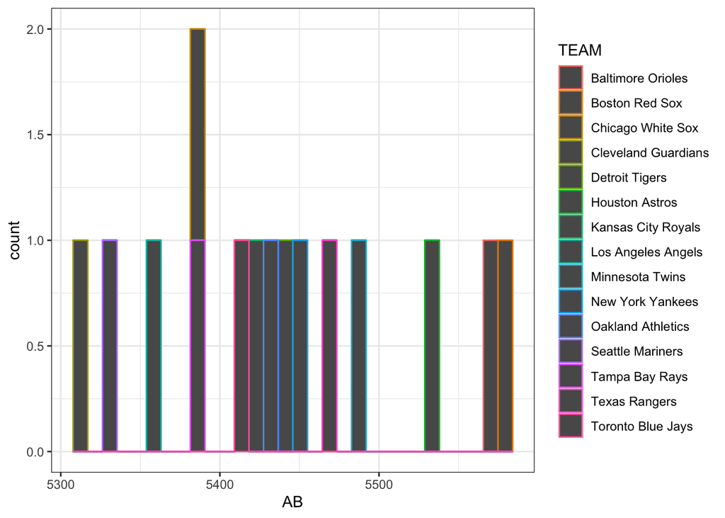

##### Análisis comparativo estadístico (AB)

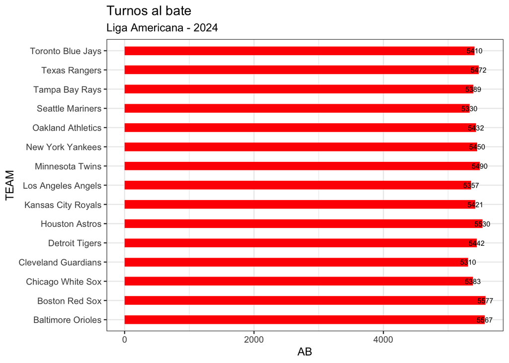

##### ¿Qué equipo consumió más turnos al bate?

```
[1] "Boston Red Sox"
```

##### ¿Cuántos consumieron?

Tal como nos indica nuestro resumen inicial de las estadísticas descriptivas, el valor máximo es de:

```
[1] 5577
```

##### ¿Qué equipo consumió menos turnos al bate?

```
[1] "Cleveland Guardians"
```

##### ¿Cuántos consumieron?

Tal como nos indica nuestro resumen inicial de las estadísticas descriptivas, el valor mínimo es de:

```
[1] 5310
```

## HITS (H)

##### Resumen estadísticas descriptivas (H)

```
   Min. 1st Qu.  Median    Mean 3rd Qu.    Max.
   1187    1252    1302    1303    1352    1448
```

Los valores máximos (1.448) y valores mínimos (1.187) son el indicador de los extremos de nuestra variable Hit.

25% de los equipos se encuentran por debajo de los 1.252 hits y el 75% por debajo de 1.352

Encontramos una media y mediana casi idénticas, lo que nos hace referirnos a que los datos de los **Hits** estan distribuidos de manera uniforme o simétrica alrededor del centro tal como se mostrará en la figura a continuación:

##### Distribución de Frecuencia (H)

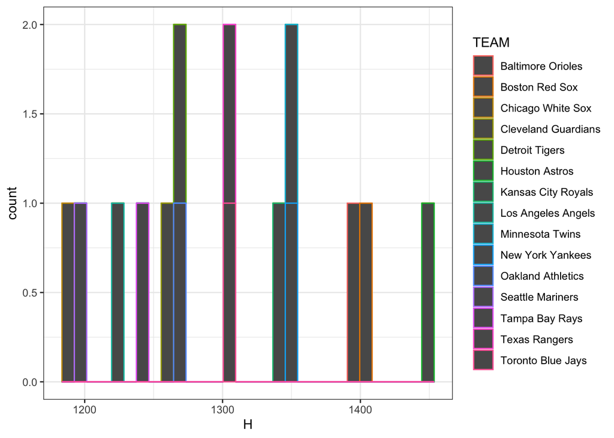

##### Análisis comparativo estadístico (H)

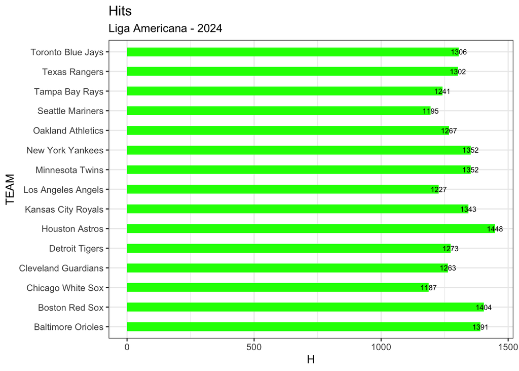

##### ¿Qué equipo conectó más hits?

```
[1] "Houston Astros"
```

##### ¿Cuántos conectaron?

Tal como nos indica nuestro resumen inicial de las estadísticas descriptivas, el valor máximo es de:

```
[1] 1448
```

##### ¿Qué equipo conectó menos hits?

```
[1] "Chicago White Sox"
```

##### ¿Cuántos conectaron?

Tal como nos indica nuestro resumen inicial de las estadísticas descriptivas, el valor mínimo es de:

```
[1] 1187
```

## CUADRANGULARES (HR)

##### Resumen estadísticas descriptivas (HR)

```
   Min. 1st Qu.  Median    Mean 3rd Qu.    Max.
  133.0   163.5   183.0   180.9   192.0   237.0
```

Los valores máximos (237) y valores mínimos (133) son el indicador de los extremos de nuestra variable Cuadrangulares.

25% de los equipos se encuentran por debajo de los 163.5 cuadrangulares y el 75% por debajo de 192.

Encontramos una media y mediana casi idénticas, lo que nos hace referirnos a que los datos de los **Cuadrangulares** estan distribuidos de manera uniforme o simétrica alrededor del centro tal como se mostrará en la figura a continuación:

##### Distribución de Frecuencia (HR)

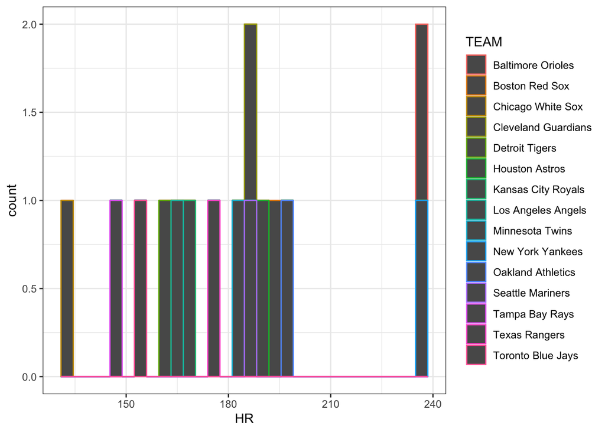

##### Análisis comparativo estadístico (HR)

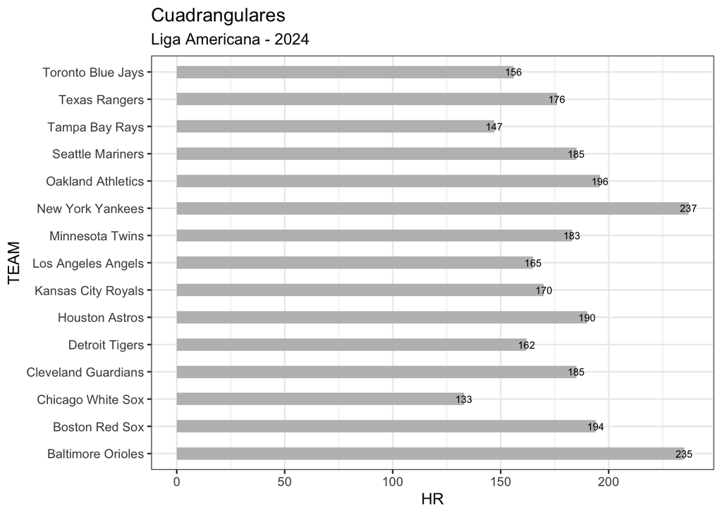

##### ¿Qué equipo conectó más cuadrangulares?

```
[1] "New York Yankees"
```

##### ¿Cuántos conectaron?

Tal como nos indica nuestro resumen inicial de las estadísticas descriptivas, el valor máximo es de:

```
[1] 237
```

##### ¿Qué equipo conectó menos cuadrangulares?

```
[1] "Chicago White Sox"
```

##### ¿Cuántos conectaron?

Tal como nos indica nuestro resumen inicial de las estadísticas descriptivas, el valor mínimo es de:

```
[1] 133
```

## PROMEDIO AL BATE (AVG)

```
   Min. 1st Qu.  Median    Mean 3rd Qu.    Max.
  221.0   231.5   238.0   239.5   248.0   262.0
```

Los valores máximos (.262) y valores mínimos (.221) son el indicador de los extremos de nuestra variable promedio al bate.

25% de los equipos se encuentran por debajo de los 231.5 de average y el 75% por debajo de 248.

Encontramos una media y mediana casi idénticas, lo que nos hace referirnos a que los datos de los **Promedios al Bate** estan distribuidos de manera uniforme o simétrica alrededor del centro tal como se mostrará en la figura a continuación:

##### Distribución de Frecuencia (AVG)

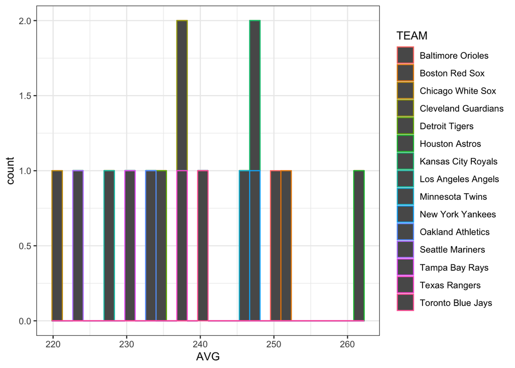

##### Análisis comparativo estadístico (AVG)

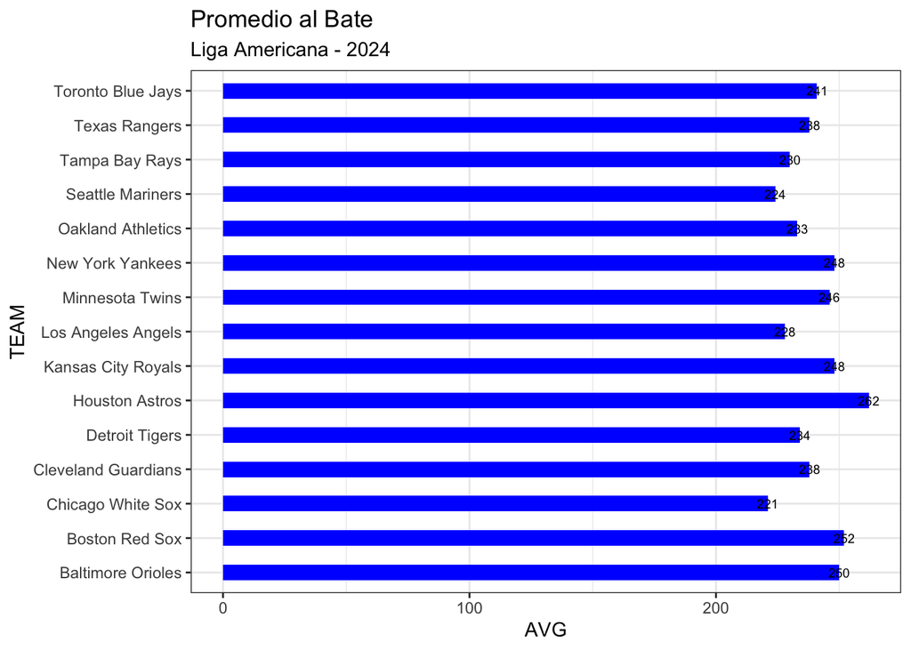

##### ¿Qué equipo promedió más average?

```
[1] "Houston Astros"
```

##### ¿Cuánto promedió?

Tal como nos indica nuestro resumen inicial de las estadísticas descriptivas, el valor máximo es de:

```
[1] 262
```

##### ¿Qué equipo promedió menos average?

```
[1] "Chicago White Sox"
```

##### ¿Cuánto promedió?

Tal como nos indica nuestro resumen inicial de las estadísticas descriptivas, el valor mínimo es de:

```
[1] 221
```

## PORCENTAJE DE EMBASADO (OBP)

```
   Min. 1st Qu.  Median    Mean 3rd Qu.    Max.
  278.0   301.5   307.0   308.5   315.0   333.0
```

25% de los equipos se encuentran por debajo de los 301.5 de average y el 75% por debajo de 315.

Encontramos una media y mediana casi idénticas, lo que nos hace referirnos a que los datos de los **Porcentajes de Embasados** estan distribuidos de manera uniforme o simétrica alrededor del centro tal como se mostrará en la figura a continuación:

##### Distribución de Frecuencia (OBP)

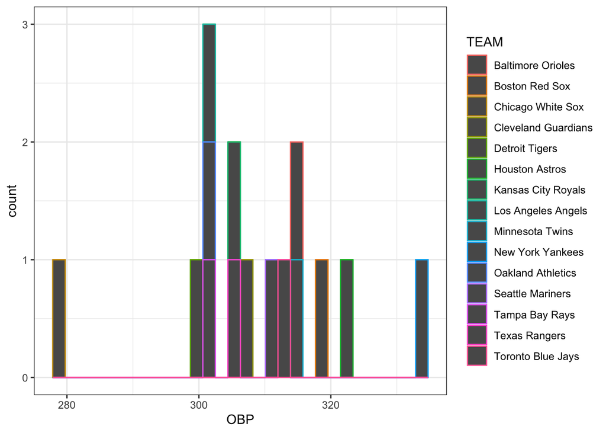

##### Análisis comparativo estadístico (OBP)

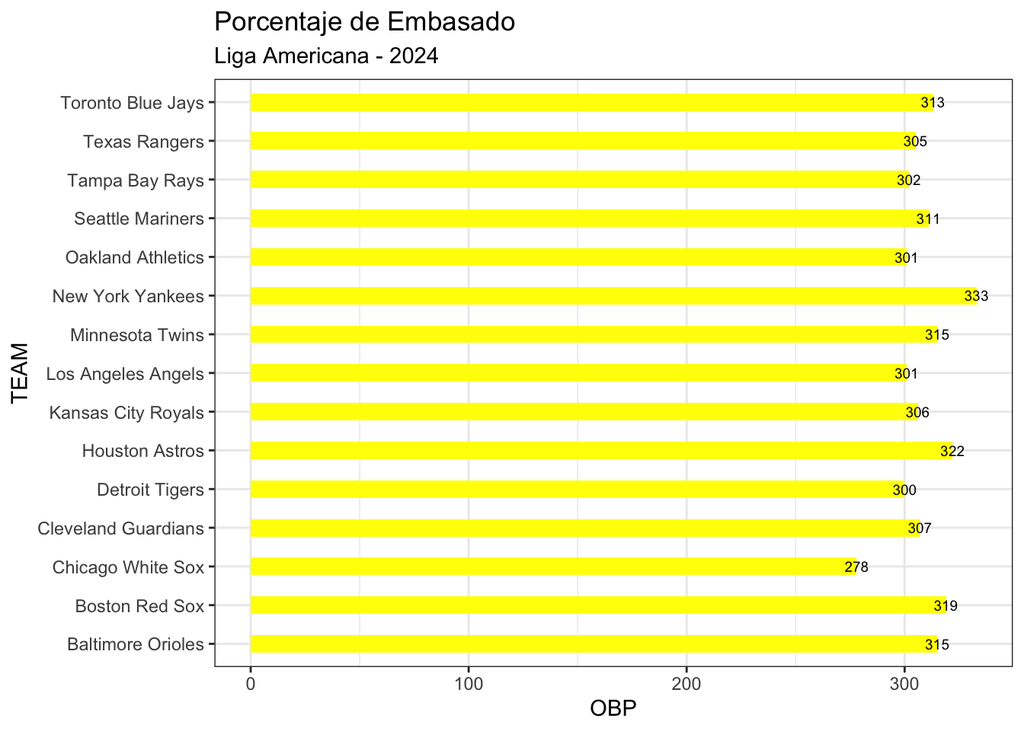

##### ¿Qué equipo promedió más porcentaje de embasado?

```
[1] "New York Yankees"
```

##### ¿Cuánto promedió?

Tal como nos indica nuestro resumen inicial de las estadísticas descriptivas, el valor máximo es de:

```
[1] 333
```

##### ¿Qué equipo promedió menos porcentaje de embasado?

```
[1] "Chicago White Sox"
```

##### ¿Cuánto promedió?

Tal como nos indica nuestro resumen inicial de las estadísticas descriptivas, el valor mínimo es de:

```
[1] 278
```

#### Slugging (SLG)

```
   Min. 1st Qu.  Median    Mean 3rd Qu.    Max.
  340.0   378.0   393.0   394.1   414.5   435.0
```

25% de los equipos se encuentran por debajo de los 378 de average y el 75% por debajo de 414.5.

Encontramos una media y mediana casi idénticas, lo que nos hace referirnos a que los datos del **Slugging** estan distribuidos de manera uniforme o simétrica alrededor del centro tal como se mostrará en la figura a continuación:

##### Distribución de Frecuencia (SLG)

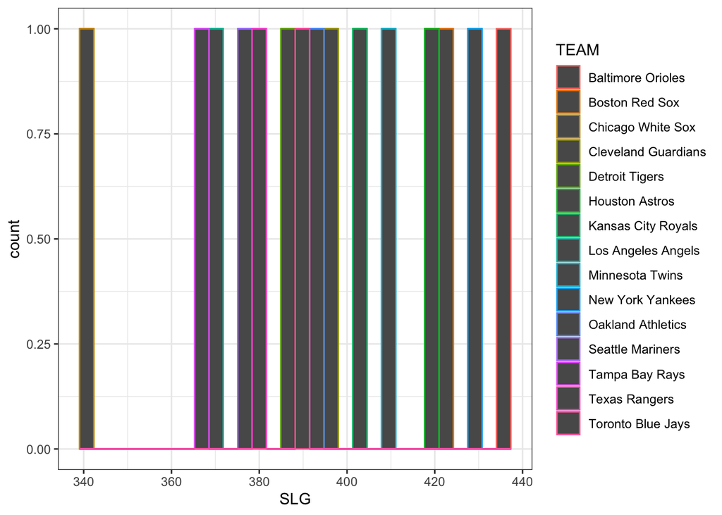

##### Análisis comparativo estadístico (SLG)

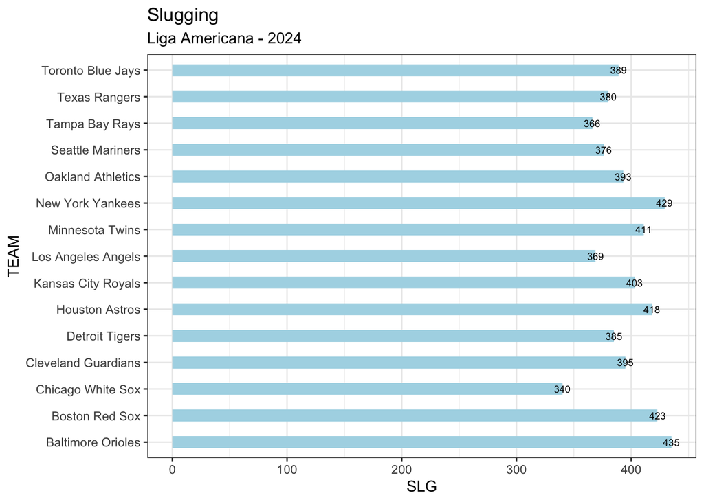

##### ¿Qué equipo promedió más Slugging?

```
[1] "Baltimore Orioles"
```

##### ¿Cuánto promedió?

Tal como nos indica nuestro resumen inicial de las estadísticas descriptivas, el valor máximo es de:

```
[1] 435
```

##### ¿Qué equipo promedió menos Slugging?

```
[1] "Chicago White Sox"
```

##### ¿Cuánto promedió?

Tal como nos indica nuestro resumen inicial de las estadísticas descriptivas, el valor mínimo es de:

```
[1] 340
```

## ¿QUÉ TAN CIERTO ES QUE EL EQUIPO QUE CONECTE MAYOR NÚMERO DE CUADRANGULARES TENDRÁ UN MAYOR PROMEDIO AL BATE?

Para ello, analicemos un gráfico de dispersión entre los cuadrangulares (HR) y el promedio al bate (AVG).

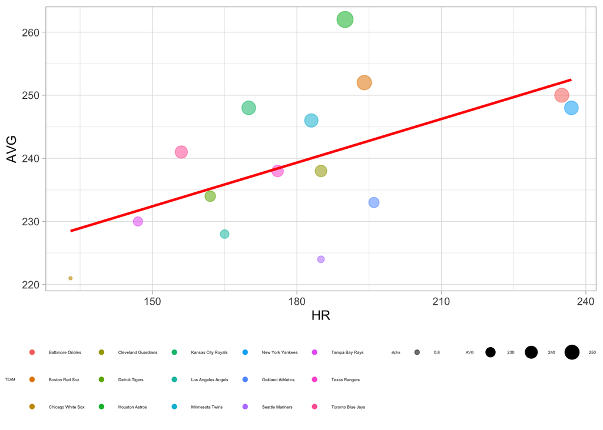

El gráfico nos muestra una relación positiva aunque moderada por las distancias reflejada de los puntos hacia la linea de tendencia, a medida que el número de cuadrangulares aumenta, incrementa el AVG. Sin embargo, observamos un valor (New York Yankees) que rompe esta relación debido a que es el que mayor cuadrangulares posee pero no es el que mayor promedio al bate (AVG) posee.

Por otra parte, Chicago White Sox es el equipo menos cuadrangulares conectó y coincide en que es el que menos AVG posee. Por lo que la relación AVG-HR es positiva pero no es del todo concluyente para responder a nuestras interrogantes porque el número de cuadrangulares no define directamente el promedio al bate.

## Y… ¿LA RELACIÓN HITS - AVG SI DEFINE EL PROMEDIO AL BATE?

Para ello, analicemos un gráfico de dispersión entre los hits (H) y el promedio al bate (AVG).

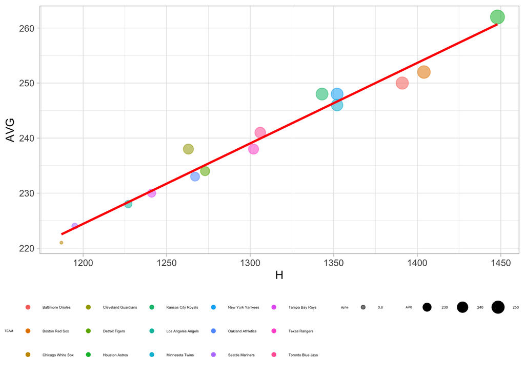

El gráfico nos muestra una relación positiva y fuerte por el comportamiento lineal reflejado por los puntos y la linea de tendencia, a medida que el número de hits aumenta, incrementa el AVG. Observamos que la relacion se evidencia con los Astros de Houston que es el equipo que más hits conectó y, a su vez, el que posee mayor promedio ofensivo.

Por otra parte, Chicago White Sox es el equipo menos hits conectó y coincide en que es el que menos AVG posee. Por lo que la relación AVG-H es positiva, directa y el número de hits si define el mayor promedio al bate de cada equipo.

## SIN EMBARGO, EXISTE UNA VARIABLE DENOMINADA “OPS” QUE PROFUNDIZA NUESTRO ANÁLISIS OFENSIVO

El OPS permite evaluar la capacidad ofensiva colectiva de cada franquicia en la MLB. Los equipos con los mejores OPS incluyen valores que rondan los **.750**, lo que indica una ofensiva fuerte y productiva.

Se obtiene sumando el porcentaje de embasado (**OBP**) y el porcentaje de slugging (**SLG**).

#### Nueva tabla interactiva con OPS añadida

|  | TEAM | LEAGUE | AB | H | HR | AVG | OBP | SLG | OPS |
| --- | --- | --- | --- | --- | --- | --- | --- | --- | --- |
| 1 | New York Yankees | AL | 5450 | 1352 | 237 | 248 | 333 | 429 | 762 |
| 2 | Baltimore Orioles | AL | 5567 | 1391 | 235 | 250 | 315 | 435 | 750 |
| 3 | Oakland Athletics | AL | 5432 | 1267 | 196 | 233 | 301 | 393 | 694 |
| 4 | Boston Red Sox | AL | 5577 | 1404 | 194 | 252 | 319 | 423 | 742 |
| 5 | Houston Astros | AL | 5530 | 1448 | 190 | 262 | 322 | 418 | 740 |
| 6 | Cleveland Guardians | AL | 5310 | 1263 | 185 | 238 | 307 | 395 | 702 |
| 7 | Seattle Mariners | AL | 5330 | 1195 | 185 | 224 | 311 | 376 | 687 |
| 8 | Minnesota Twins | AL | 5490 | 1352 | 183 | 246 | 315 | 411 | 726 |
| 9 | Texas Rangers | AL | 5472 | 1302 | 176 | 238 | 305 | 380 | 685 |
| 10 | Kansas City Royals | AL | 5421 | 1343 | 170 | 248 | 306 | 403 | 709 |

[output cut: 5 more lines]

```
   Min. 1st Qu.  Median    Mean 3rd Qu.    Max.
  618.0   685.0   702.0   702.7   733.0   762.0
```

## ¿QUÉ EQUIPOS POSEEN UN OPS SUPERIOR A .750?

```
# A tibble: 15 × 10
   TEAM         LEAGUE    AB     H    HR   AVG   OBP   SLG   OPS Rendimiento_OPS
   <chr>        <chr>  <dbl> <dbl> <dbl> <dbl> <dbl> <dbl> <dbl> <chr>
 1 New York Ya… AL      5450  1352   237   248   333   429   762 Por_encima
 2 Baltimore O… AL      5567  1391   235   250   315   435   750 Por_encima
 3 Oakland Ath… AL      5432  1267   196   233   301   393   694 Por_debajo
 4 Boston Red … AL      5577  1404   194   252   319   423   742 Por_debajo
 5 Houston Ast… AL      5530  1448   190   262   322   418   740 Por_debajo
 6 Cleveland G… AL      5310  1263   185   238   307   395   702 Por_debajo
 7 Seattle Mar… AL      5330  1195   185   224   311   376   687 Por_debajo
 8 Minnesota T… AL      5490  1352   183   246   315   411   726 Por_debajo
 9 Texas Range… AL      5472  1302   176   238   305   380   685 Por_debajo
10 Kansas City… AL      5421  1343   170   248   306   403   709 Por_debajo
11 Los Angeles… AL      5357  1227   165   228   301   369   670 Por_debajo
12 Detroit Tig… AL      5442  1273   162   234   300   385   685 Por_debajo
13 Toronto Blu… AL      5410  1306   156   241   313   389   702 Por_debajo
14 Tampa Bay R… AL      5389  1241   147   230   302   366   668 Por_debajo
15 Chicago Whi… AL      5383  1187   133   221   278   340   618 Por_debajo
```

El restante de 13 equipos se encuentra por debajo de un OPS de .750, el más bajo de todos es Chicago White Sox con un OPS de .618 que se encuentra incluso por debajo de la media de todos los equipos.

## RELACIÓN OPS - H

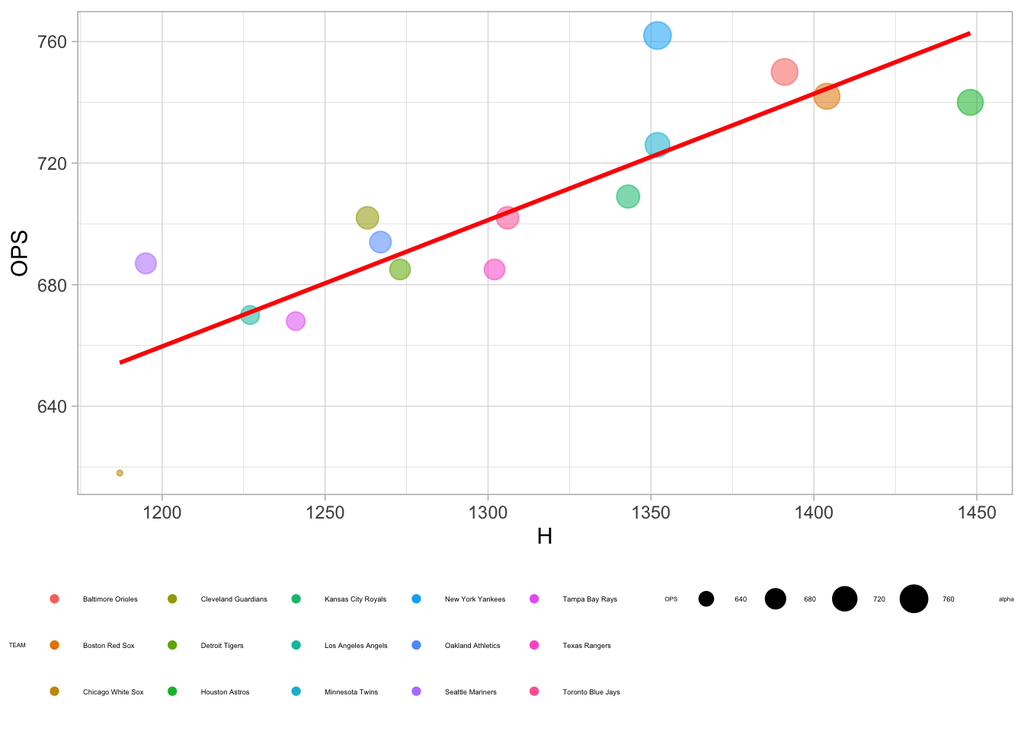

El gráfico nos muestra una relación positiva y moderada, a medida que el el numero de hits aumenta, incrementa el OPS. Sin embargo, observamos un valor (New York Yankees) que rompe esta relación debido a que es el que mayor OPS posee pero no es el que mayor número de hits conecta.

Por otra parte, Chicago White Sox es el equipo menos hits conectó y coincide en que es el que menos OPS posee. Por lo que la relación OPS-H es positiva pero no es del todo concluyente para responder a nuestras interrogantes.

## RELACIÓN OPS - HR

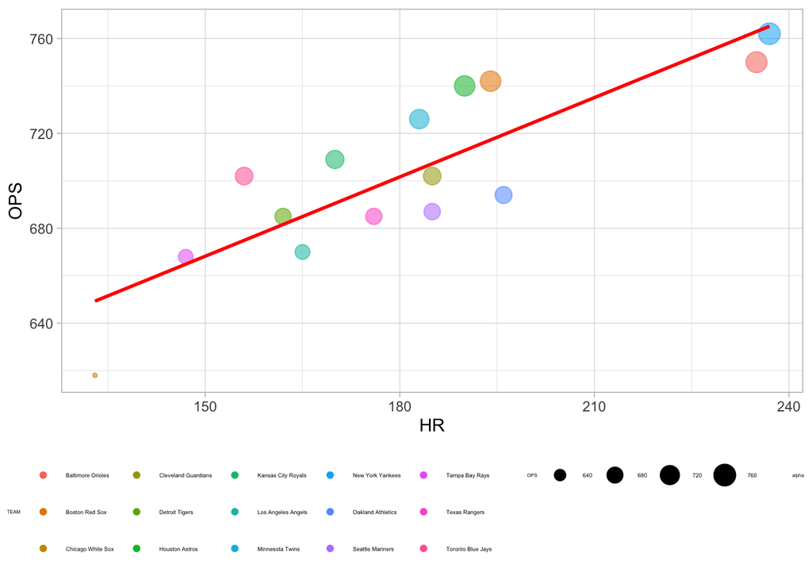

El gráfico nos muestra una relación positiva y moderada con un carácter más lineal que el anterior, a medida que el el numero de cuadrangulares aumenta, incrementa el OPS. Esto, se evidencia en el valor más grande de cuadrangulares que lo posee New York Yankees y que, evidentemente, posee el valor mayor de OPS.

En el mismo sentido, Chicago White Sox es el equipo menos cuadrangulares conectó y, efectivamente, es el que menos OPS posee. Por lo que la relación OPS-HR es directa.

## RESULTADOS Y CONCLUSIONES

##### 1. ¿Qué equipo fue la mejor ofensiva del año 2024 en la MLB?

La respuesta a esta interrogante debe partir por dos variables principales AVG y OPS. La primera nos refleja el equipo que mejor promedio ofensivo obtuvo en la temporada 2024, en este caso, y basado en la relación lineal directa AVG-H, **Astros de Houston** fue el equipo que mejor ofensivo en cuánto a hits y average resultó de la campaña de la MLB 2024 en la Liga Americana.

Por otra parte, en términos de producción, capacidad de llegar a base y poder en sus batazos, los **New York Yankees** dominaron el circuito en términos de HR y OPS en la campaña de la MLB 2024 en la Liga Americana.

Finalmente, hemos seleccionado a estos dos equipos como las mejores ofensivas de la última temporada de las grandes ligas en el análisis realizado a la liga americana.

##### 2. ¿Qué equipo fue la peor ofensiva del año 2024 en la MLB?

La respuesta puede resultar evidente luego de nuestro análisis ejercido a través de la exploración de nuestros datos previamente realizado. **Chicago White Sox** fue el peor equipo ofensivo de la liga americana en el año 2024 en hits, cuadrangulares, porcentaje de embasado, slugging y OPS.